# Microbial Compositional Analysis Along A Salinity Gradient

Liangzi

2025-04-23

**INTERPRETATION #1: What are the limitations of interpreting microbial abundance from relative (aka. compositional) rather than absolute counts?**

- Relative abundances always sum to 100%, meaning an increase in one taxon automatically implies a decrease in others—even if their absolute counts didn’t change. This can introduce false correlations and distort real ecological patterns.
- Also, we might lose information about sequencing depth or biomass, so we can’t determine whether overall microbial load changed. This is especially problematic if some samples had drastically higher/lower DNA concentrations or total reads.
- Relative abundance is still useful for comparative purposes, but it’s best paired with absolute quantification (e.g., qPCR, spike-ins) when the goal is to understand total microbial load or track true growth/decline.

# Setup

## Load Packages

```r
# Load in the packages
pacman::p_load(tidyverse, devtools, DT, phyloseq, patchwork,
               install = FALSE)

# load colors
source("code/colors.R")
```

## 1. Load in Scaled Phyloseq object

```r
load("data/06_Ordination/scaled_physeq.RData")

# Look at the data
scaled_physeq
```

```
## phyloseq-class experiment-level object
## otu_table()   OTU Table:         [ 2114 taxa and 19 samples ]
## sample_data() Sample Data:       [ 19 samples by 40 sample variables ]
## tax_table()   Taxonomy Table:    [ 2114 taxa by 9 taxonomic ranks ]
## phy_tree()    Phylogenetic Tree: [ 2114 tips and 2113 internal nodes ]
```

```r
# Intuition check - scaled at 1,942
min(sample_sums(scaled_physeq))
```

```
## [1] 24183
```

```r
range(sample_sums(scaled_physeq))
```

```
## [1] 24183 24226
```

# Taxonomic Analysis!

## A. Phylum

```r
# Create a phylum level dataframe
phylum_df <-
  scaled_physeq %>%
  tax_glom(taxrank = "Phylum") %>%
  transform_sample_counts(function(x) {x / sum(x)}) %>%
  psmelt() %>%
  mutate(Collection_Date = fct_relevel(as.character(Collection_Date), c("2019-06-03", "2019-06-08", "2019-06-14", "2019-06-15", "2019-06-20")),   # Convert date to character before releveling
         # If oxygen_level is numeric, convert to factor first
         oxygen_level = fct_relevel(as.factor(oxygen_level), c("5", "10", "20", "25")))

## What are the phylum abundances?
phylum_df %>%
  group_by(Phylum) %>%
  summarize(mean_PercAbund = round(mean(Abundance), digits = 4)) %>%
  arrange(-mean_PercAbund) %>%
  datatable()
```

[output not shown]

[output cut: 21 more lines]

```r
# Make a list of phyla the top phyla
top10_phyla <-
  phylum_df %>%
  group_by(Phylum) %>%
  summarize(mean_PercAbund = mean(Abundance)) %>%
  arrange(-mean_PercAbund) %>%
  head(n = 10) %>%
  pull(Phylum)
```

**INTERPRETATION #2: Which phyla in your dataset have the highest relative abundances? What are their abundances? We will focus on these phyla for plotting below.**

Based on the table of mean relative abundances at the phylum level: The most abundant phyla in the dataset is Pseudomonadota (75.58%). The table suggests a highly uneven distribution, dominated primarily by Pseudomonadota (75.58%), Bacteroidota (15.22%), Bacillota (4.58%) and Chloroflexota (2%).

## Stacked Bar plots

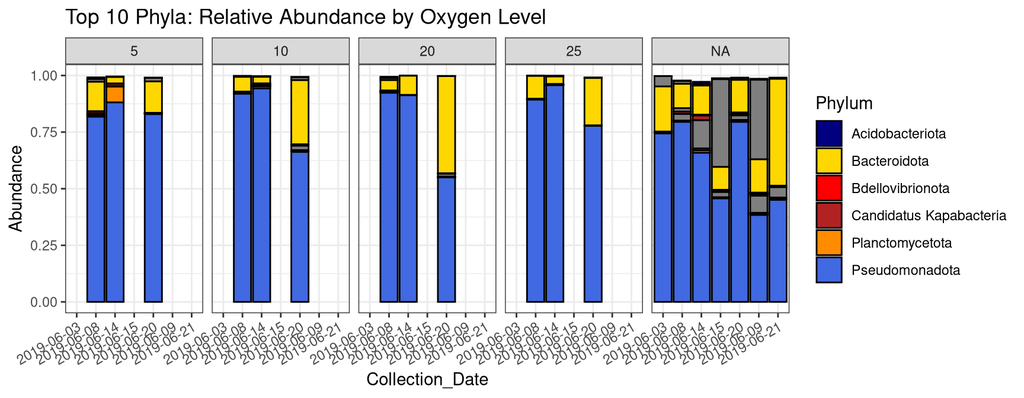

```r
# Stacked Bar Plot With All phyla
# Plot Phylum Abundances - make sure to load phylum_colors
phylum_df %>%
  dplyr::filter(Phylum %in% top10_phyla) %>%
  ggplot(aes(x = Collection_Date, y = Abundance, fill = Phylum)) +
  facet_grid(.~oxygen_level) +
  geom_bar(stat = "identity", color = "black") +
  labs(title = "Top 10 Phyla: Relative Abundance by Oxygen Level") +
  scale_fill_manual(values = phylum_colors) +
  theme_bw() +
  theme(axis.text.x = element_text(angle = 30, hjust = 1, vjust = 1))
```

## Faceted Bar plot

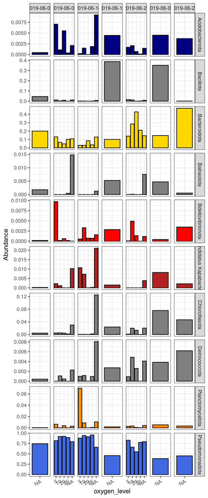

```r
phylum_df %>%
  dplyr::filter(Phylum %in% top10_phyla) %>%
  # Individual sample comparison of surface waters, whole fraction
  # This will allow us to look at individual samples!
  # Note that whenever plotting stacked bar plots, you should always look at Individual samples!
  ggplot(aes(x = oxygen_level, y = Abundance, fill = Phylum)) +
  facet_grid(Phylum~Collection_Date, scale = "free") +
  # add the stacked bar
  geom_bar(stat = "identity", color = "black") +
  # change the colors to be our selected colors
  scale_fill_manual(values = phylum_colors) +
  theme_bw() +
  theme(legend.position = "none",
        axis.text.x = element_text(angle = 30, hjust = 1, vjust = 1))
```

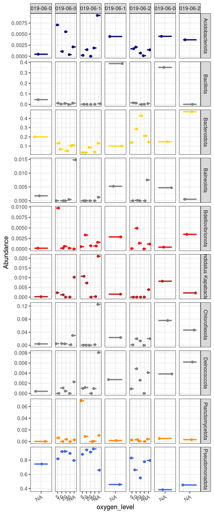

```r
### Or combined together:
phylum_df %>%
  dplyr::filter(Phylum %in% top10_phyla) %>%
  ggplot(aes(x = oxygen_level, y = Abundance, fill = Phylum, color = Phylum)) +
  facet_grid(Phylum~Collection_Date, scale = "free") +
  # add the stacked bar
  geom_jitter() +
  geom_boxplot(outlier.shape = NA, alpha = 0.5) +
  # change the colors to be our selected colors
  scale_fill_manual(values = phylum_colors) +
  scale_color_manual(values = phylum_colors) +
  theme_bw() +
  theme(legend.position = "none",
        axis.text.x = element_text(angle = 30, hjust = 1, vjust = 1))
```

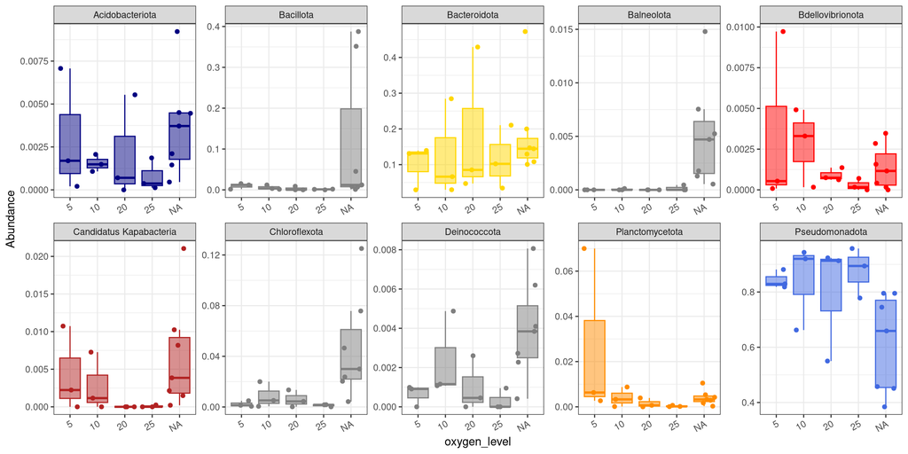

```r
### Or combined together:
phylum_df %>%
  dplyr::filter(Phylum %in% top10_phyla) %>%
  ggplot(aes(x = oxygen_level, y = Abundance, fill = Phylum, color = Phylum)) +
  facet_wrap(Phylum~., scales = "free", nrow = 2) +
  # add the stacked bar
  geom_jitter() +
  geom_boxplot(outlier.shape = NA, alpha = 0.5) +
  # change the colors to be our selected colors
  scale_fill_manual(values = phylum_colors) +
  scale_color_manual(values = phylum_colors) +
  theme_bw() +
  theme(legend.position = "none",
        axis.text.x = element_text(angle = 30, hjust = 1, vjust = 1))
```

**INTERPRETATION #3: Make the above dotplot and boxplot for your sample types and your most abundant phyla. What initial conclusions can you draw regarding the sampled microbial communities as it relates to your scientific question?**

*Bacillota & Chloroflexota:* Patchy and variable distributions. These groups may reflect more specialized metabolic roles that are sensitive to oxygen concentration or influenced by other environmental co-factors like substrate availability.

*Candidatus Kapabacteria:* Appears at low relative abundance but shows fluctuations across oxygen levels. May be part of the rare biosphere, possibly opportunistic or responding to subtle micro-niches.

*Pseudomonadota:* Consistently dominant across all oxygen levels (especially visible in the boxplot). Shows high abundance even under low-oxygen conditions, suggesting broad ecological tolerance or metabolic versatility.

*Key finding:* - The microbial community in the bioreactor samples is clearly structured by oxygen level, with several phyla showing differential abundance patterns. - Dominant taxa like Pseudomonadota and Bacteroidota may play key functional roles and thrive under a range of oxygen conditions. Other taxa show oxygen-dependent shifts, suggesting ecological filtering, niche specialization, or sensitivity to redox gradients.

**After initial exploration, we focus on specific phyla that appear to vary across oxygen levels. These targeted plots help develop hypotheses about ecological drivers:** Bacteroidota, Chloroflexota, Bacillota, Pseudomonadota.

### A1. Bacteroidota

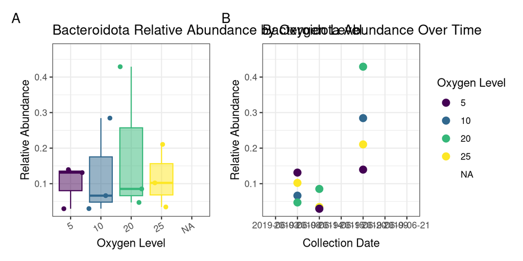

```r
# Bacteroidota: Boxplot and dotplot by oxygen level (CATEGORICAL)
Bactero_phylum_oxygen <-
  phylum_df %>%
  dplyr::filter(Phylum == "Bacteroidota") %>%
  ggplot(aes(x = factor(oxygen_level), y = Abundance,
             fill = factor(oxygen_level), color = factor(oxygen_level))) +
  geom_boxplot(alpha = 0.5, outlier.shape = NA) +
  geom_jitter() +
  theme_bw() +
  labs(title = "Bacteroidota Relative Abundance by Oxygen Level",
       x = "Oxygen Level", y = "Relative Abundance") +
  scale_color_viridis_d() +
  scale_fill_viridis_d() +
  theme(axis.text.x = element_text(angle = 30, hjust = 1, vjust = 1),
        legend.position = "none")

# Bacteroidota: Trend over continuous Collection_Date (CONTINUOUS)
Bactero_phylum_date <-
  phylum_df %>%
  dplyr::filter(Phylum == "Bacteroidota") %>%
  ggplot(aes(x = Collection_Date, y = Abundance)) +
  geom_point(aes(color = factor(oxygen_level)), size = 3) +
  geom_smooth(method = "lm", formula = y ~ poly(as.numeric(x), 2)) +
  labs(title = "Bacteroidota Abundance Over Time",
       x = "Collection Date", y = "Relative Abundance") +
  scale_color_viridis_d(name = "Oxygen Level") +
  theme_bw() +
  theme(legend.position = "right")

# Combine the plots
Bactero_phylum_oxygen + Bactero_phylum_date +
  plot_layout(guides = "collect") +
  plot_annotation(tag_levels = "A")
```

Bacteroidota Abundance Across Oxygen Level and Collection Date

### A2: Chloroflexota

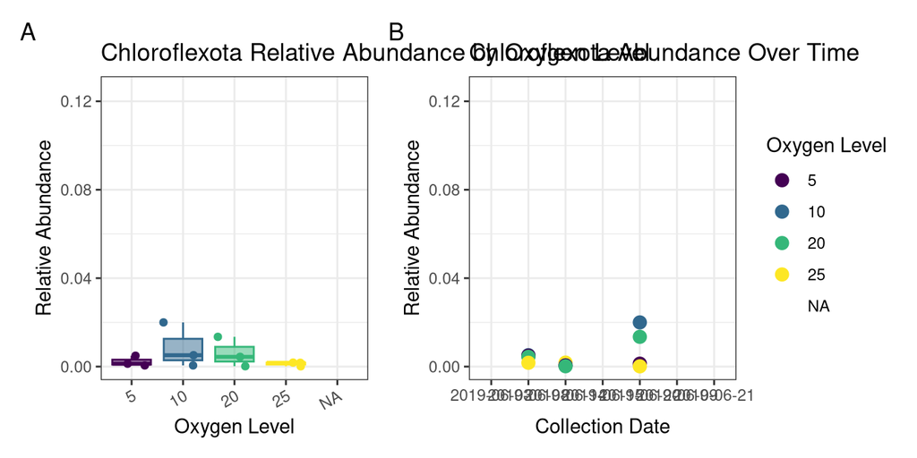

```r
# Chloroflexota: Boxplot and dotplot by oxygen level (CATEGORICAL)
Chloro_phylum_oxygen <-
  phylum_df %>%
  dplyr::filter(Phylum == "Chloroflexota") %>%
  ggplot(aes(x = factor(oxygen_level), y = Abundance,
             fill = factor(oxygen_level), color = factor(oxygen_level))) +
  geom_boxplot(alpha = 0.5, outlier.shape = NA) +
  geom_jitter() +
  theme_bw() +
  labs(title = "Chloroflexota Relative Abundance by Oxygen Level",
       x = "Oxygen Level", y = "Relative Abundance") +
  scale_color_viridis_d() +
  scale_fill_viridis_d() +
  theme(axis.text.x = element_text(angle = 30, hjust = 1, vjust = 1),
        legend.position = "none")

# Chloroflexota: Trend over continuous Collection_Date (CONTINUOUS)
Chloro_phylum_date <-
  phylum_df %>%
  dplyr::filter(Phylum == "Chloroflexota") %>%
  ggplot(aes(x = Collection_Date, y = Abundance)) +
  geom_point(aes(color = factor(oxygen_level)), size = 3) +
  geom_smooth(method = "lm", formula = y ~ poly(as.numeric(x), 2)) +
  labs(title = "Chloroflexota Abundance Over Time",
       x = "Collection Date", y = "Relative Abundance") +
  scale_color_viridis_d(name = "Oxygen Level") +
  theme_bw() +
  theme(legend.position = "right")

# Combine the plots
Chloro_phylum_oxygen + Chloro_phylum_date +
  plot_layout(guides = "collect") +
  plot_annotation(tag_levels = "A")
```

Chloroflexota Abundance Across Oxygen Level and Collection Date

Chloroflexota are often abundant members of the biomass in wastewater treatment plants. In activated sludge systems, changes in oxygen concentration can influence the relative abundance of Chloroflexota and other bacteria. Their growth and metabolic activity are affected by the presence and concentration of oxygen. Their response to oxygen level helps indicate shifts in primary production potential.

### A3: Bacillota

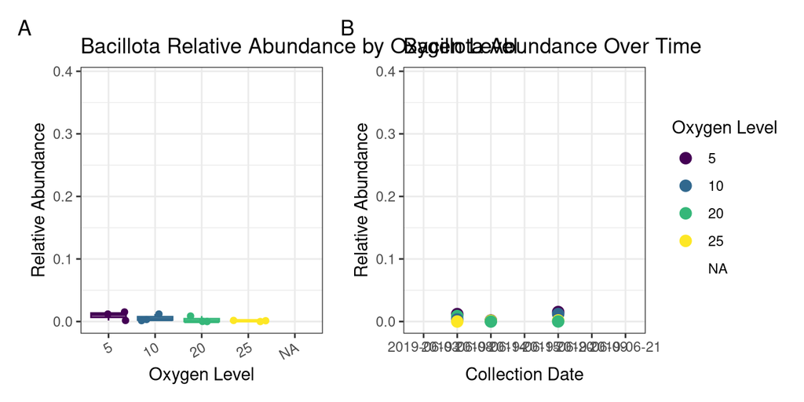

```r
# Deinococcota: Boxplot and dotplot by oxygen level (CATEGORICAL)
Bacill_phylum_oxygen <-
  phylum_df %>%
  dplyr::filter(Phylum == "Bacillota") %>%
  ggplot(aes(x = factor(oxygen_level), y = Abundance,
             fill = factor(oxygen_level), color = factor(oxygen_level))) +
  geom_boxplot(alpha = 0.5, outlier.shape = NA) +
  geom_jitter() +
  theme_bw() +
  labs(title = "Bacillota Relative Abundance by Oxygen Level",
       x = "Oxygen Level", y = "Relative Abundance") +
  scale_color_viridis_d() +
  scale_fill_viridis_d() +
  theme(axis.text.x = element_text(angle = 30, hjust = 1, vjust = 1),
        legend.position = "none")

# Bacillota: Trend over continuous Collection_Date (CONTINUOUS)
Bacill_phylum_date <-
  phylum_df %>%
  dplyr::filter(Phylum == "Bacillota") %>%
  ggplot(aes(x = Collection_Date, y = Abundance)) +
  geom_point(aes(color = factor(oxygen_level)), size = 3) +
  geom_smooth(method = "lm", formula = y ~ poly(as.numeric(x), 2)) +
  labs(title = "Bacillota Abundance Over Time",
       x = "Collection Date", y = "Relative Abundance") +
  scale_color_viridis_d(name = "Oxygen Level") +
  theme_bw() +
  theme(legend.position = "right")

# Combine the plots
Bacill_phylum_oxygen + Bacill_phylum_date +
  plot_layout(guides = "collect") +
  plot_annotation(tag_levels = "A")
```

Bacillota Abundance Across Oxygen Levels and Collection Date

A. Bacillota relative abundance remains consistently very low across all oxygen levels, with only minor fluctuations. There is a slight decrease in abundance at higher oxygen levels (20–25), but the overall abundance remains low (<0.03) throughout. This suggests that oxygen concentration does not strongly drive Bacillota dynamics in this system. B. Over time, Bacillota abundance also remains consistently low, with no major peaks or drops across the sampling dates. The low variability indicates that Bacillota populations are relatively stable but minor community members in this dataset.

### A4. Pseudomonadota

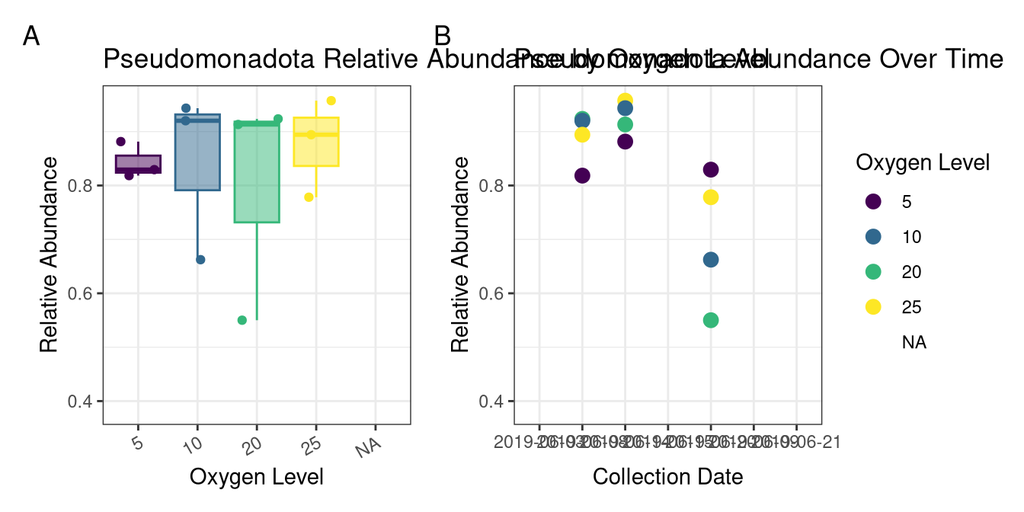

```r
# Pseudomonadota: Boxplot and dotplot by oxygen level (CATEGORICAL)
actino_phylum_oxygen <-
  phylum_df %>%
  dplyr::filter(Phylum == "Pseudomonadota") %>%
  ggplot(aes(x = factor(oxygen_level), y = Abundance,
             fill = factor(oxygen_level), color = factor(oxygen_level))) +
  geom_boxplot(alpha = 0.5, outlier.shape = NA) +
  geom_jitter() +
  theme_bw() +
  labs(title = "Pseudomonadota Relative Abundance by Oxygen Level",
       x = "Oxygen Level", y = "Relative Abundance") +
  scale_color_viridis_d() +
  scale_fill_viridis_d() +
  theme(axis.text.x = element_text(angle = 30, hjust = 1, vjust = 1),
        legend.position = "none")

# Pseudomonadota: Trend over continuous Collection_Date (CONTINUOUS)
actino_phylum_date <-
  phylum_df %>%
  dplyr::filter(Phylum == "Pseudomonadota") %>%
  ggplot(aes(x = Collection_Date, y = Abundance)) +
  geom_point(aes(color = factor(oxygen_level)), size = 3) +
  geom_smooth(method = "lm", formula = y ~ poly(as.numeric(x), 2)) +
  labs(title = "Pseudomonadota Abundance Over Time",
       x = "Collection Date", y = "Relative Abundance") +
  scale_color_viridis_d(name = "Oxygen Level") +
  theme_bw() +
  theme(legend.position = "right")

# Combine the plots
actino_phylum_oxygen + actino_phylum_date +
  plot_layout(guides = "collect") +
  plot_annotation(tag_levels = "A")
```

Pseudomonadota Abundance Across Oxygen Levels and Collection Date

A. Pseudomonadota relative abundance is consistently high across all oxygen levels, but there is a slight increasing trend from low (5) to higher (25) oxygen concentrations. While the overall abundance remains elevated (>0.8 in most samples), the spread (variance) increases at intermediate oxygen levels, suggesting some environmental variability influencing this group at those conditions. B. Over time, Pseudomonadota abundance peaks around mid-sampling dates and slightly decreases toward the later sampling points. However, the abundance remains relatively high across all collection dates, indicating that Pseudomonadota are a stable, dominant group in these microbial communities throughout the sampling period.

**INTERPRETATION #4: Based on these phylum-level analyses, were there any phyla that you were able to identify to focus on moving forward for deeper taxonomic analyses? Why?**

Yes, based on the phylum-level analyses of my dataset, Pseudomonadota emerged as the most informative candidates for deeper taxonomic exploration.

Pseudomonadota dominated nearly all samples, showing both high abundance and variability. While their ubiquity might make them less informative for biogeographic structuring alone, their dominance suggests a critical role in bioreactor microbial dynamics. Zooming in on genus- or species-level variation could help identify key players in bioprocessing functions.

## B. Genus

```r
# Calculate the Family relative abundance
# Note: The read depth MUST be normalized in some way: scale_reads
genus_df <-
  scaled_physeq %>%
  # agglomerate at the phylum level
  tax_glom(taxrank = "Genus") %>%
  # Transform counts to relative abundance
  transform_sample_counts(function (x) {x/sum(x)}) %>%
  # Melt to a long format
  psmelt() %>%
  # Fix the order of date
  mutate(Collection_Date = fct_relevel(as.character(Collection_Date), c("2019-06-03", "2019-06-08", "2019-06-14", "2019-06-15", "2019-06-20")),
    oxygen_level = fct_relevel(as.factor(oxygen_level), c("5", "10", "20", "25")))
```

### B1. Pseudomonadota Genera

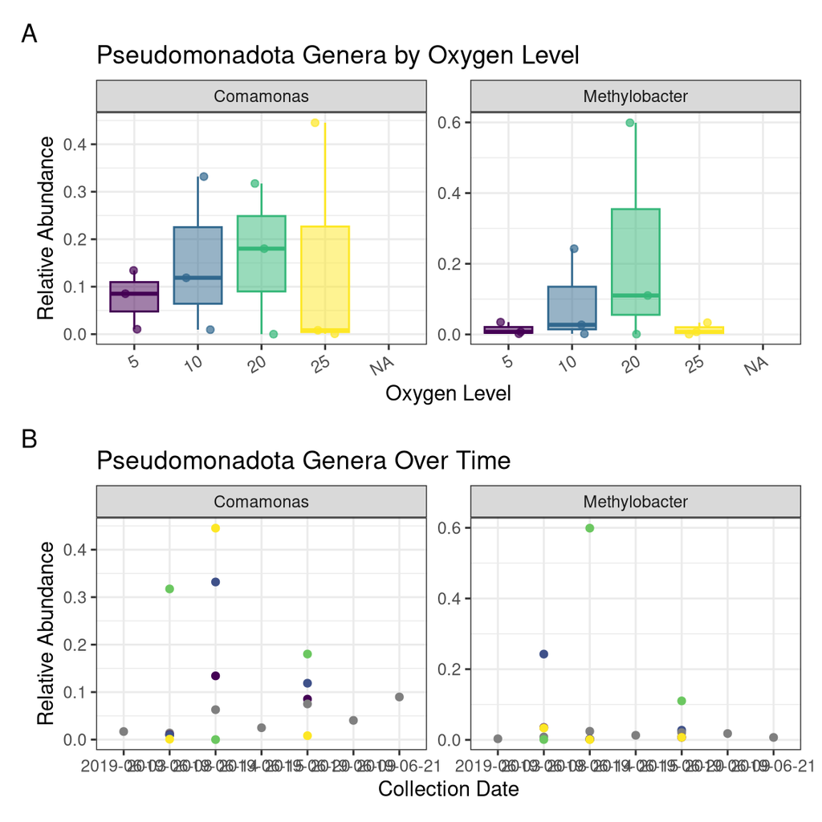

```r
# Pseudomonadota
# Plot genus
Pseudo_genus_oxygen <-
  genus_df %>%
  dplyr::filter(Phylum == "Pseudomonadota") %>%
  # At first, plot all of the genera and then subset the ones that have intersting trends
  dplyr::filter(Genus %in% c("Methylobacter", "Comamonas")) %>%
  # build the plot
  ggplot(aes(x = factor(oxygen_level), y = Abundance,
             fill = factor(oxygen_level), color = factor(oxygen_level))) +
  facet_wrap(. ~ Genus, scales = "free_y", nrow = 1) +
  geom_boxplot(alpha = 0.5, outlier.shape = NA) +
  geom_jitter(width = 0.2, alpha = 0.7) +
  labs(title = "Pseudomonadota Genera by Oxygen Level",
       x = "Oxygen Level", y = "Relative Abundance") +
  scale_color_viridis_d() +
  scale_fill_viridis_d() +
  theme_bw() +
  theme(axis.text.x = element_text(angle = 30, hjust = 1),
        legend.position = "none")

# Plot genus: Continuous
Pseudo_genus_date <-
  genus_df %>%
  dplyr::filter(Phylum == "Pseudomonadota") %>%
  dplyr::filter(Genus %in% c("Methylobacter", "Comamonas")) %>%
  ggplot(aes(x = Collection_Date, y = Abundance)) +
  facet_wrap(. ~ Genus, scales = "free_y", nrow = 1) +
  geom_point(aes(color = as.numeric(as.character(oxygen_level)))) +
  scale_color_viridis_c(option = "D") +
  geom_smooth(method = "lm", formula = y ~ poly(x, 2)) +
  labs(title = "Pseudomonadota Genera Over Time",
       x = "Collection Date", y = "Relative Abundance") +
  scale_color_viridis_c(option = "D") +
  theme_bw() +
  theme(legend.position = "none")
# Collect the Pseudomonadota Plots
Pseudo_genus_oxygen / Pseudo_genus_date +
  plot_layout(guides = "collect") +
  plot_annotation(tag_levels = "A")
```

**INTERPRETATION #5: Please make some plots of mid-level taxonomic ranks (e.g. Genus, Family, Order) as it relates to your scientific question. Were there any changes in the mid-level taxonomic trends compared to the phylum-level results? What does that tell you about that taxonomic group?**

Together, these patterns support a hypothesis that oxygen concentration is a key environmental filter acting on Pseudomonadota genera, driving distinct abundance patterns that reflect metabolic specialization or tolerance.

## C. ASV level

```r
# Calculate the Family relative abundance
# Note: The read depth MUST be normalized in some way: scale_reads
ASV_df <-
  scaled_physeq %>%
  ## LOOK AT HOW MANY ARE REMOVED! We scaled to 24,199 reads!
  prune_taxa(taxa_sums(.) >= 2419, .) %>%
  # agglomerate at the phylum level
  tax_glom(taxrank = "ASV") %>%
  # Transform counts to relative abundance
  transform_sample_counts(function (x) {x/sum(x)}) %>%
  # Melt to a long format
  psmelt() %>%
  # fix the order of date
  mutate(Collection_Date = fct_relevel(as.character(Collection_Date), c("2019-06-03", "2019-06-08", "2019-06-14", "2019-06-15", "2019-06-20")),
         oxygen_level = fct_relevel(as.factor(oxygen_level), c("5", "10", "20", "25")))
```

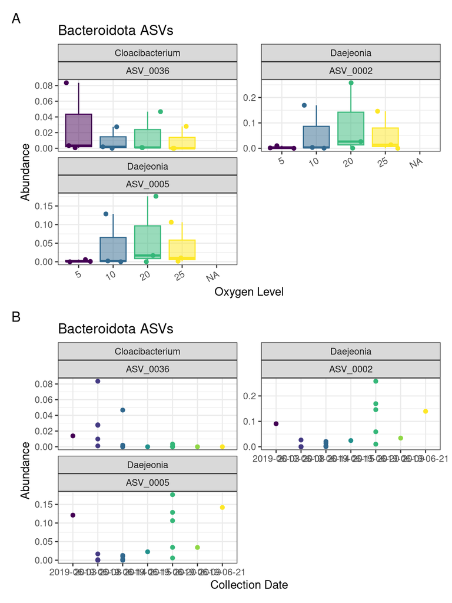

```r
# Calculate top couple of ASVs
# Make a list of phyla the top phyla
top_Bactero_ASVs <-
  ASV_df %>%
  dplyr::filter(Phylum == "Bacteroidota") %>%
  dplyr::filter(Genus %in% c("Daejeonia", "Cloacibacterium")) %>%
  group_by(ASV) %>%
  summarize(mean_Abundance = mean(Abundance)) %>%
  dplyr::filter(mean_Abundance > 0.005) %>%
  pull(ASV)

# Bacteroidota
# Plot ASVs
Bactero_asv_oxygen <-
  ASV_df %>%
  dplyr::filter(ASV %in% top_Bactero_ASVs) %>%
  # build the plot
  ggplot(aes(x = factor(oxygen_level), y = Abundance,
             fill = factor(oxygen_level), color = factor(oxygen_level))) +
  facet_wrap(Genus~ASV, scales = "free_y", nrow = 2) +
  geom_boxplot(alpha = 0.5, outlier.shape = NA) + # outliers not plotted here in boxplot
  geom_jitter() +
  theme_bw() +
  labs(title = "Bacteroidota ASVs", x = "Oxygen Level", y = "Abundance") +
  scale_color_viridis_d() +
  scale_fill_viridis_d() +
  theme(axis.text.x = element_text(angle = 30, hjust = 1, vjust = 1),
        legend.position = "none")

# Plot ASVs: Continuous
Bactero_asv_date <-
  ASV_df %>%
  dplyr::filter(ASV %in% top_Bactero_ASVs) %>%
  # build the plot
  ggplot(aes(x = Collection_Date, y = Abundance)) +
  facet_wrap(Genus~ASV, scales = "free_y", nrow = 2) +
  geom_point(aes(color = Collection_Date)) +
  scale_color_viridis_d(option = "D") +
  theme_bw() +
  geom_smooth(method = "lm",  formula = y ~ poly(x, 2)) +
  labs(title = "Bacteroidota ASVs", x = "Collection Date", y = "Abundance") +
  scale_color_viridis_d(option = "D") +
  theme(legend.position = "none")
# Collect the Bacteroidota Plots
Bactero_asv_oxygen / Bactero_asv_date +
  plot_layout(guides = "collect") +
  plot_annotation(tag_levels = "A")
```

### C2. Chloroflexota ASVs

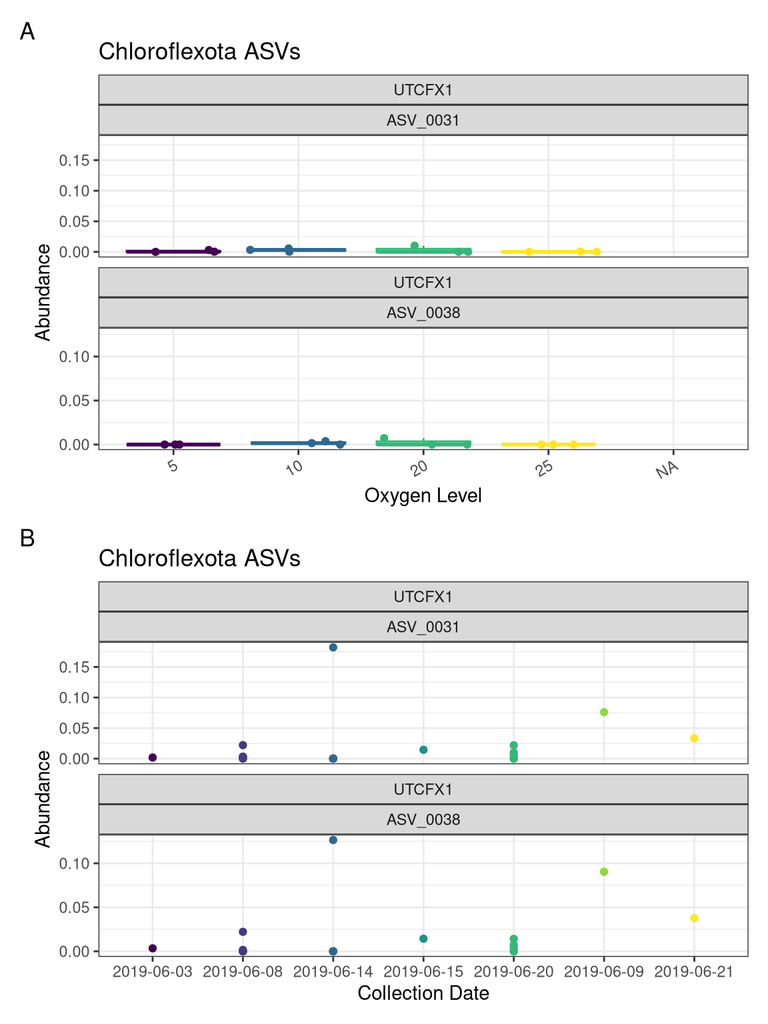

```r
# Calculate top couple of ASVs
# Make a list of phyla the top phyla
top_Chloro_ASVs <-
  ASV_df %>%
  dplyr::filter(Phylum == "Chloroflexota") %>%
  dplyr::filter(Genus %in% c("UTCFX1")) %>%
  group_by(ASV) %>%
  summarize(mean_Abundance = mean(Abundance)) %>%
  dplyr::filter(mean_Abundance > 0.005) %>%
  pull(ASV)

# Chloroflexota
# Plot ASVs
Chloro_asv_oxygen <-
  ASV_df %>%
  dplyr::filter(ASV %in% top_Chloro_ASVs) %>%
  # build the plot
  ggplot(aes(x = factor(oxygen_level), y = Abundance,
             fill = factor(oxygen_level), color = factor(oxygen_level))) +
  facet_wrap(Genus~ASV, scales = "free_y", nrow = 2) +
  geom_boxplot(alpha = 0.5, outlier.shape = NA) + # outliers not plotted here in boxplot
  geom_jitter() +
  theme_bw() +
  labs(title = "Chloroflexota ASVs", x = "Oxygen Level", y = "Abundance") +
  scale_color_viridis_d() +
  scale_fill_viridis_d() +
  theme(axis.text.x = element_text(angle = 30, hjust = 1, vjust = 1),
        legend.position = "none")

# Plot ASVs: Continuous
Chloro_asv_date <-
  ASV_df %>%
  dplyr::filter(ASV %in% top_Chloro_ASVs) %>%
  # build the plot
  ggplot(aes(x = Collection_Date, y = Abundance)) +
  facet_wrap(Genus~ASV, scales = "free_y", nrow = 2) +
  geom_point(aes(color = Collection_Date)) +
  scale_color_viridis_d(option = "D") +
  theme_bw() +
  geom_smooth(method = "lm",  formula = y ~ poly(x, 2)) +
  labs(title = "Chloroflexota ASVs", x = "Collection Date", y = "Abundance") +
  scale_color_viridis_d(option = "D") +
  theme(legend.position = "none")
# Collect the Bacteroidota Plots
Chloro_asv_oxygen / Chloro_asv_date +
  plot_layout(guides = "collect") +
  plot_annotation(tag_levels = "A")
```

### C3. Bacillota ASVs

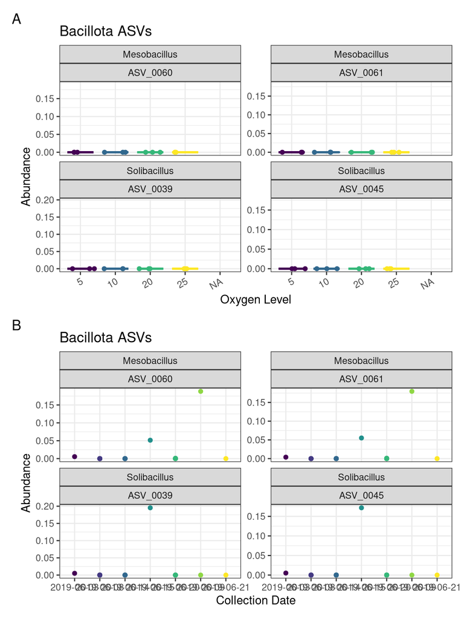

```r
# Calculate top couple of ASVs
# Make a list of phyla the top phyla
top_Bacill_ASVs <-
  ASV_df %>%
  dplyr::filter(Phylum == "Bacillota") %>%
  dplyr::filter(Genus %in% c("Mesobacillus", "Solibacillus")) %>%
  group_by(ASV) %>%
  summarize(mean_Abundance = mean(Abundance)) %>%
  dplyr::filter(mean_Abundance > 0.005) %>%
  pull(ASV)

# Bacillota
# Plot ASVs
Bacill_asv_oxygen <-
  ASV_df %>%
  dplyr::filter(ASV %in% top_Bacill_ASVs) %>%
  # build the plot
  ggplot(aes(x = factor(oxygen_level), y = Abundance,
             fill = factor(oxygen_level), color = factor(oxygen_level))) +
  facet_wrap(Genus~ASV, scales = "free_y", nrow = 2) +
  geom_boxplot(alpha = 0.5, outlier.shape = NA) + # outliers not plotted here in boxplot
  geom_jitter() +
  theme_bw() +
  labs(title = "Bacillota ASVs", x = "Oxygen Level", y = "Abundance") +
  scale_color_viridis_d() +
  scale_fill_viridis_d() +
  theme(axis.text.x = element_text(angle = 30, hjust = 1, vjust = 1),
        legend.position = "none")

# Plot ASVs: Continuous
Bacill_asv_date <-
  ASV_df %>%
  dplyr::filter(ASV %in% top_Bacill_ASVs) %>%
  # build the plot
  ggplot(aes(x = Collection_Date, y = Abundance)) +
  facet_wrap(Genus~ASV, scales = "free_y", nrow = 2) +
  geom_point(aes(color = Collection_Date)) +
  scale_color_viridis_d(option = "D") +
  theme_bw() +
  geom_smooth(method = "lm",  formula = y ~ poly(x, 2)) +
  labs(title = "Bacillota ASVs", x = "Collection Date", y = "Abundance") +
  scale_color_viridis_d(option = "D") +
  theme(legend.position = "none")
# Collect the Bacteroidota Plots
Bacill_asv_oxygen / Bacill_asv_date +
  plot_layout(guides = "collect") +
  plot_annotation(tag_levels = "A")
```

### C4. Pseudomonadota ASVs

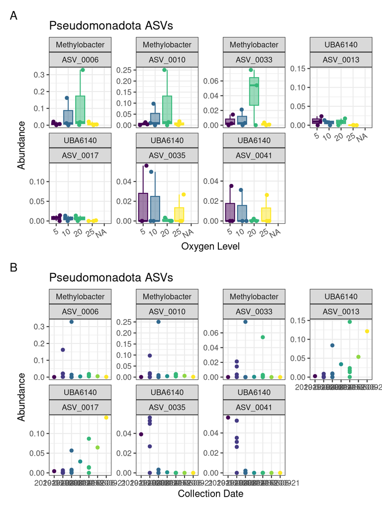

```r
# Calculate top couple of ASVs
# Make a list of phyla the top phyla
top_Pseudo_ASVs <-
  ASV_df %>%
  dplyr::filter(Phylum == "Pseudomonadota") %>%
  dplyr::filter(Genus %in% c("UBA6140", "Methylobacter")) %>%
  group_by(ASV) %>%
  summarize(mean_Abundance = mean(Abundance)) %>%
  dplyr::filter(mean_Abundance > 0.005) %>%
  pull(ASV)

# Pseudomonadota
# Plot ASVs
Pseudo_asv_oxygen <-
  ASV_df %>%
  dplyr::filter(ASV %in% top_Pseudo_ASVs) %>%
  # build the plot
  ggplot(aes(x = factor(oxygen_level), y = Abundance,
             fill = factor(oxygen_level), color = factor(oxygen_level))) +
  facet_wrap(Genus~ASV, scales = "free_y", nrow = 2) +
  geom_boxplot(alpha = 0.5, outlier.shape = NA) + # outliers not plotted here in boxplot
  geom_jitter() +
  theme_bw() +
  labs(title = "Pseudomonadota ASVs", x = "Oxygen Level", y = "Abundance") +
  scale_color_viridis_d() +
  scale_fill_viridis_d() +
  theme(axis.text.x = element_text(angle = 30, hjust = 1, vjust = 1),
        legend.position = "none")

# Plot ASVs: Continuous
Pseudo_asv_date <-
  ASV_df %>%
  dplyr::filter(ASV %in% top_Pseudo_ASVs) %>%
  # build the plot
  ggplot(aes(x = Collection_Date, y = Abundance)) +
  facet_wrap(Genus~ASV, scales = "free_y", nrow = 2) +
  geom_point(aes(color = Collection_Date)) +
  scale_color_viridis_d(option = "D") +
  theme_bw() +
  geom_smooth(method = "lm",  formula = y ~ poly(x, 2)) +
  labs(title = "Pseudomonadota ASVs", x = "Collection Date", y = "Abundance") +
  scale_color_viridis_d(option = "D") +
  theme(legend.position = "none")
# Collect the Pseudomonadota Plots
Pseudo_asv_oxygen / Pseudo_asv_date +
  plot_layout(guides = "collect") +
  plot_annotation(tag_levels = "A")
```

Yes, at least one of the most abundant ASVs was represented in the ASV-level plots. ASV_0006, which is visible in the Pseudomonadota plot, appears to be among the most abundant ASVs in the dataset based on its high relative abundance.

**INTERPRETATION #7: Please make some plots at the ASV level as it relates to your scientific question. Were there any ASVs that were especially related to trends that you saw? Did a specific phylogenetic group all show the same trends? Or did the ASVs have various, likely niche-specific responses?**

*Bacteroidota: Abundant but varied* ASV_0002 and ASV_0005 (Daejeonia) show high relative abundance, particularly under moderate oxygen levels (10–20). ASV_0036 (Cloacibacterium) remains lower overall but also shows some oxygen-level association. These patterns suggest ecological filtering by oxygen, but also genus-specific preferences.

**INTERPRETATION #8: Now, do a quick literature or google search and look back in the paper that you may be replicating (if applicable). Does your ASV-level changes represent something that is currently known? Or is this a novel result? What did you learn about this ASV or a group of ASVs in your dataset?**

For Pseudomonadota: Pseudomonas is a multi-functional genus containing many species that have anaerobic or aerobic denitrification abilities. Based on the ASV-level analysis, I found that this diverse group includes ASVs that are generalists, thriving across a range of oxygen levels. Their consistent presence suggests metabolic versatility, allowing them to adapt to varying oxygen conditions.

For Bacteroidota and Bacillota: These phyla may display varied responses. Some ASVs might be more prevalent in low-oxygen environments, indicating potential roles in anaerobic processes. But most of the ASVs might be more prevalent in high-oxygen environments, indicating potential roles in aerobic processes.

For Chloroflexota: These ASVs showed low abundance over all oxygen levels. These taxa are consistently present in low numbers and may become active under specific environmental conditions not captured in your sampling. This pattern suggests a preference for both aerobic and anaerobic environments and aligns with their known metabolic capabilities in degrading recalcitrant organic matter under oxic conditions.

These observations indicate that while some ASVs have niche-specific responses to oxygen availability, others maintain stable populations regardless of oxygen levels, highlighting the complexity of microbial community dynamics.